# ML2_ESA_QP

## April 2022: END SEMESTER ASSESSMENT (ESA)

### M.TECH DATA SCIENCE AND MACHINE LEARNING_ SEMESTER II

## UE20CS931 - MACHINE LEARNING - II

A non-profit healt organization has collected data baout patients in a diabetic speciality hospital, recently has turned into a covid-cure center. The organization has to see if there is any pattern to classify the patiets who has survived and passed away. Given below is the detail of the dataset.

Detail of the dataset

Patient I.D. --> Index of patient enrolment number

Age --> Age of the patient

Sex --> Gender of the patient

cp --> Chest Pain type chest pain type

trtbps --> resting blood pressure (in mm Hg)

chol --> cholestoral in mg/dl fetched via BMI sensor

fbs --> fasting blood sugar , which has been categorised into three group based on a different magnitude

restecg --> resting electrocardiographic results

thalachh --> maximum heart rate achieved

Addiction --> Addiction of the patient

keratin_type --> Keratin type of the patient

Diabetes_type --> type of diabetes of the patient

Hemoglobin_level --> level of hemoglobin of the patient

blood_group --> Blood group of the patient

Immunity_level --> Immunity level of the patient,which has been categorised into different group

Affected_portion --> Portion of organ effect by virus

Breath_ratio --> state air to the time of inhalation ratio.

Survive --> whether a patient has overcome or passed away

```python
# pip install imblearn
```

```python
import numpy as np
import pandas as pd
import seaborn as sns
import matplotlib.pyplot as plt
from scipy import stats
from sklearn.tree import DecisionTreeClassifier
from sklearn.neighbors import KNeighborsClassifier
from sklearn.linear_model import LogisticRegression
from sklearn.ensemble import RandomForestClassifier
from sklearn.naive_bayes import GaussianNB
from xgboost import XGBClassifier
from sklearn.model_selection import cross_val_score,KFold
from imblearn.over_sampling import SMOTE
from imblearn.under_sampling import NearMiss
from imblearn.pipeline import make_pipeline
from sklearn.model_selection import GridSearchCV
from sklearn.model_selection import train_test_split
from scipy import stats
from sklearn.tree import DecisionTreeClassifier
from sklearn.neighbors import KNeighborsClassifier
from sklearn.linear_model import LogisticRegression
from sklearn.ensemble import RandomForestClassifier
from sklearn.naive_bayes import GaussianNB
from xgboost import XGBClassifier
from sklearn.model_selection import cross_val_score,KFold
from imblearn.over_sampling import SMOTE
from imblearn.under_sampling import NearMiss
from imblearn.pipeline import make_pipeline
from sklearn.model_selection import GridSearchCV
```

```python
data = pd.read_csv("dataset.csv")
data.head()
```

|  | Patient I.D. | Age | Sex | cp | trtbps | chol | fbs | restecg | thalachh | Addiction | keratin_type | Diabetes_type | Hemoglobin_level | blood_group | Immunity_level | Affected_portion | Breath_ratio | Survive |
| --- | --- | --- | --- | --- | --- | --- | --- | --- | --- | --- | --- | --- | --- | --- | --- | --- | --- | --- |
| 0 | 1 | 29.0 | Male | 1 | 6.613849 | 240.859519 | 1 | 1 | 113.0895308 | Nicotine - type A | 3 | type 2 | 7 | O- | 1 | 41.576901 | 21.55 | Survived |
| 1 | 2 | 30.0 | Female | 1 | 8.789486 | 253.220968 | 3 | 2 | 113.3518612 | Nicotine - type A | 2 | type 1 | 6 | B- | 4 | 43.234092 | 24.23 | Survived |
| 2 | 3 | 29.0 | Male | 2 | 10.376325 | 237.148027 | 2 | 1 | 106.9501548 | Drug-type B | 2 | type 3 | 8 | B- | 4 | 46.758422 | 44.97 | Survived |
| 3 | 4 | 30.0 | Male | 3 | 18.336148 | 245.179914 | 3 | 2 | 100.4835624 | Alcohol | 2 | type 2 | 13 | O+ | 2 | 47.254223 | 47.24 | Survived |
| 4 | 5 | 29.0 | Female | 1 | 17.285610 | 233.539891 | 2 | 2 | 122.7902658 | Nicotine - type A | 2 | type 1 | 6 | AB+ | 2 | 27.046348 | 28.74 | Survived |

## Section B (marks 30)

### 2(i). Read the dataset and print the following (6 marks)

```
 *Shape of the data (1 mark)
 * Number of numerical and categorical variable (1 mark)
 * Descriptive stats of numerical data (1 mark)
 * Descriptive stats of categorical data  (1 mark)
 * Summarize observations for categorical variables – no. of categories, % observations in each category. (2 mark)
```

#### Shape of the data (1 mark)

```python
data.shape
```

```
(7000, 18)
```

#### Number of numerical and categorical variable (1 mark)

```python
num_values = data.select_dtypes(include=["number"]).columns
cat_values = data.select_dtypes(include=["object","category"]).columns
print("Numerical Values: ", num_values)
print("\nLength of Numerical Values: ", len(num_values))
print("\nCategorical Values: ",cat_values)
print("\nLength of Categorical Values: ",len(cat_values))
```

```
Numerical Values:  Index(['Patient I.D.', 'Age', 'cp', 'trtbps', 'chol', 'fbs', 'restecg',
       'keratin_type', 'Hemoglobin_level', 'Immunity_level',
       'Affected_portion', 'Breath_ratio'],
      dtype='object')

Length of Numerical Values:  12

Categorical Values:  Index(['Sex', 'thalachh', 'Addiction', 'Diabetes_type', 'blood_group',
       'Survive'],
      dtype='object')

Length of Categorical Values:  6
```

#### Descriptive stats of numerical data (1 mark)

```python
data[num_values].describe()
```

|  | Patient I.D. | Age | cp | trtbps | chol | fbs | restecg | keratin_type | Hemoglobin_level | Immunity_level | Affected_portion | Breath_ratio |
| --- | --- | --- | --- | --- | --- | --- | --- | --- | --- | --- | --- | --- |
| count | 7000.000000 | 6401.000000 | 7000.000000 | 7000.000000 | 6376.000000 | 7000.000000 | 7000.000000 | 7000.000000 | 7000.000000 | 7000.000000 | 7000.000000 | 6593.000000 |
| mean | 3500.500000 | 60.390564 | 1.654286 | 14.096497 | 248.497664 | 1.676714 | 0.914429 | 1.555143 | 9.518857 | 2.517000 | 40.878998 | 40.465292 |
| std | 2020.870275 | 18.420775 | 1.061300 | 5.131444 | 10.323672 | 1.159972 | 0.709753 | 0.667956 | 2.285818 | 1.116834 | 11.183186 | 11.633303 |
| min | 1.000000 | 29.000000 | 0.000000 | 1.241648 | 212.122186 | 0.000000 | 0.000000 | 1.000000 | 6.000000 | 1.000000 | 1.242888 | 3.010000 |
| 25% | 1750.750000 | 45.000000 | 1.000000 | 9.422638 | 240.673116 | 1.000000 | 0.000000 | 1.000000 | 8.000000 | 2.000000 | 33.232875 | 32.410000 |
| 50% | 3500.500000 | 64.000000 | 2.000000 | 14.669709 | 249.221050 | 2.000000 | 1.000000 | 1.000000 | 10.000000 | 3.000000 | 40.948939 | 39.890000 |
| 75% | 5250.250000 | 77.000000 | 3.000000 | 18.366243 | 255.371556 | 3.000000 | 1.000000 | 2.000000 | 12.000000 | 4.000000 | 48.629448 | 48.750000 |
| max | 7000.000000 | 91.000000 | 3.000000 | 27.644734 | 283.852277 | 3.000000 | 2.000000 | 3.000000 | 13.000000 | 4.000000 | 84.045723 | 86.030000 |

#### Descriptive stats of categorical data (1 mark)

```python
data[cat_values].describe()
```

|  | Sex | thalachh | Addiction | Diabetes_type | blood_group | Survive |
| --- | --- | --- | --- | --- | --- | --- |
| count | 7000 | 7000 | 7000 | 7000 | 7000 | 7000 |
| unique | 2 | 6925 | 7 | 3 | 8 | 2 |
| top | Male | ? | Nicotine - type A | type 1 | O+ | Survived |
| freq | 4889 | 76 | 1468 | 3670 | 2474 | 5915 |

#### Summarize observations for categorical variables – no. of categories, % observations in each category. (2 mark)

```python
print("Summary of Categorical variables:\n")
for col in cat_values:
    cat_counts = data[col].value_counts()
    cat_percentage = data[col].value_counts(normalize=True) * 100
    summary = pd.DataFrame({"Count":cat_counts, "Percentage":cat_percentage})
    print(summary)
```

```
Summary of Categorical variables:

        Count  Percentage
Sex
Male     4889   69.842857
Female   2111   30.157143
             Count  Percentage
thalachh
?               76    1.085714
113.0895308      1    0.014286
120.2429437      1    0.014286
107.364864       1    0.014286
105.6481298      1    0.014286
...            ...         ...
115.2217768      1    0.014286
103.9315254      1    0.014286
119.9819081      1    0.014286
115.2513593      1    0.014286
120.1043519      1    0.014286

[6925 rows x 2 columns]
                   Count  Percentage
Addiction
Nicotine - type A   1468   20.971429
others              1023   14.614286
Drug-type A          997   14.242857
Drug-type C          997   14.242857
Alcohol              996   14.228571
Drug-type B          989   14.128571
Nicotine - type B    530    7.571429
               Count  Percentage
Diabetes_type
type 1          3670   52.428571
type 2          2537   36.242857
type 3           793   11.328571
             Count  Percentage
blood_group
O+            2474   35.342857
B+            1394   19.914286
O-            1002   14.314286
A+             740   10.571429
AB+            586    8.371429
B-             533    7.614286
A-             197    2.814286
AB-             74    1.057143
             Count  Percentage
Survive
Survived      5915        84.5
Passed away   1085        15.5
```

### 2 (ii). Examine outliers by plotting and also by using z score. Examine is the Target variable evenly balanced. (5 Marks)

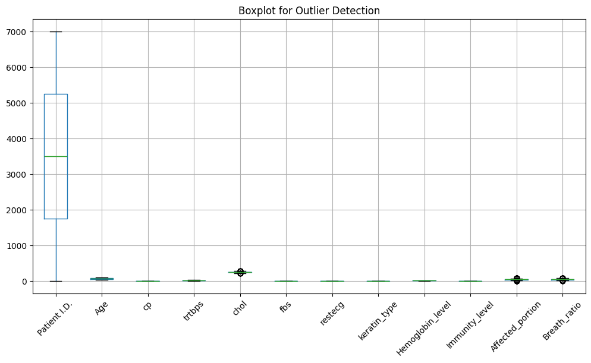

```python
plt.figure(figsize=(12,6))
data[num_values].boxplot(rot=45)
plt.title("Boxplot for Outlier Detection")
plt.show()
```

```python
from scipy.stats import zscore
z_scores = data[num_values].apply(zscore)
```

```python
outliers = (z_scores.abs() > 3).sum()
outliers_df = pd.DataFrame({"Feature":num_values, "Outliers Count":outliers.values})
```

```python
print("Outlier Summary:")
print(outliers_df.to_string(index=False))
```

```
Outlier Summary:
         Feature  Outliers Count
    Patient I.D.               0
             Age               0
              cp               0
          trtbps               0
            chol               0
             fbs               0
         restecg               0
    keratin_type               0
Hemoglobin_level               0
  Immunity_level               0
Affected_portion              21
    Breath_ratio               0
```

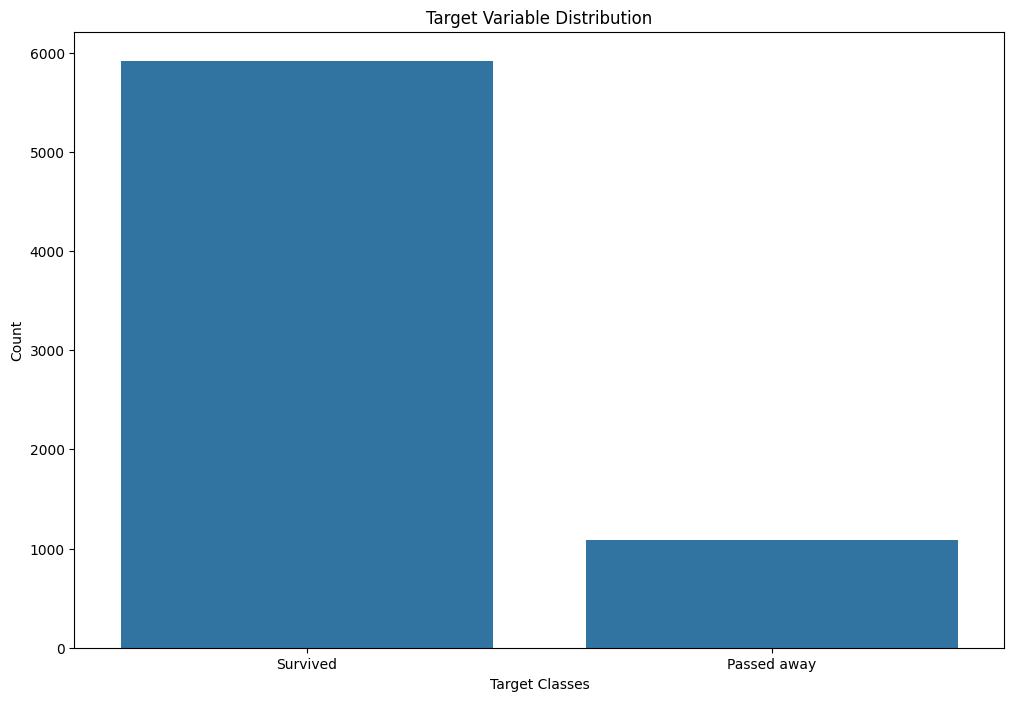

```python
target_col = data.columns[-1]
plt.figure(figsize=(12,8))
sns.countplot(x=data[target_col])
plt.title("Target Variable Distribution")
plt.xlabel("Target Classes")
plt.ylabel("Count")
plt.show()
```

```python
target_balance = data[target_col].value_counts(normalize=True) * 100
target_balance_df = pd.DataFrame({"Category":target_balance.index, "Percentage":target_balance})

print("Target Variable Balance")
print(target_balance_df.to_string(index=False))
```

```
Target Variable Balance
   Category  Percentage
   Survived        84.5
Passed away        15.5
```

### 2 (iii).Perform appropriate encoding on the categorical attributes. (5 Marks)

```python
from sklearn.preprocessing import LabelEncoder

encoded_df = data.copy()
label_encoders = {}
for col in cat_values:
    if data[col].nunique() <= 2:
        le = LabelEncoder()
        encoded_df[col] = le.fit_transform(data[col])
        label_encoders[col] = le
```

```python
encoded_df = pd.get_dummies(encoded_df, columns=[col for col in cat_values if data[col].nunique() > 2], drop_first=True)
```

```python
print("Encoded Dataset Preview")
print(encoded_df.head())
```

```
Encoded Dataset Preview
   Patient I.D.   Age  Sex  cp     trtbps        chol  fbs  restecg  \
0             1  29.0    1   1   6.613849  240.859519    1        1
1             2  30.0    0   1   8.789486  253.220968    3        2
2             3  29.0    1   2  10.376325  237.148027    2        1
3             4  30.0    1   3  18.336148  245.179914    3        2
4             5  29.0    0   1  17.285610  233.539891    2        2

   keratin_type  Hemoglobin_level  ...  Addiction_others  \
0             3                 7  ...             False
1             2                 6  ...             False
2             2                 8  ...             False
3             2                13  ...             False
4             2                 6  ...             False

```

[output cut: 22 more lines]

### 2(iv). Check for defects in the data like missing values, removing unnecessary features/columns. Perform necessary actions to ‘fix’ these defects. (6 marks)

```python
#check for missing vals
missing_values = data.isnull().sum()
missing_values_df = pd.DataFrame({"Column":data.columns,"Missing Values":missing_values,"Percentage": (missing_values /len(data)) * 100})
```

```python
#remove columns with 50% missing values
threshold = 50
cols_to_drop = missing_values_df[missing_values_df["Percentage"]> threshold]["Column"].tolist()
```

```python
#drop cols with single unique value
single_value_cols = [col for col in data.columns if data[col].nunique == 1]
cols_to_drop.extend(single_value_cols)
```

```python
#removing identified cols
cleaned_df = data.drop(columns=cols_to_drop)
```

```python
#handling missing values in remaining cols
for col in cleaned_df.columns:
    if cleaned_df[col].isnull().sum() > 0:
        if cleaned_df[col].dtype == "object" or cleaned_df[col].dtype == "category":
            cleaned_df[col].fillna(cleaned_df[col].mode()[0], inplace=True)
        else:
            cleaned_df[col].fillna(cleaned_df[col].median(), inplace=True)
```

```python
#summary of missing values after cleaning
missing_values_after = cleaned_df.isnull().sum()
missing_values_after_df = pd.DataFrame({"Column":cleaned_df.columns, "Missing Values":missing_values_after})

print("Missing Values after Cleaning")
print(missing_values_after_df.head())
```

```
Missing Values after Cleaning
                    Column  Missing Values
Patient I.D.  Patient I.D.               0
Age                    Age               0
Sex                    Sex               0
cp                      cp               0
trtbps              trtbps               0
```

```python
## Another Approach Easy
```

```python
new_cleaned_data = data.dropna(thresh=len(data) * 0.5, axis=1)
```

```python
new_cleaned_data = data.loc[:,data.nunique() > 1]
```

```python
new_cleaned_data = data.fillna(data.median(numeric_only=True))

new_cleaned_data = data.apply(lambda x:x.fillna(x.mode()[0]) if x.dtype == "object" or x.dtype == "category" else x)
```

```python
print(new_cleaned_data.head())
```

```
   Patient I.D.   Age     Sex  cp     trtbps        chol  fbs  restecg  \
0             1  29.0    Male   1   6.613849  240.859519    1        1
1             2  30.0  Female   1   8.789486  253.220968    3        2
2             3  29.0    Male   2  10.376325  237.148027    2        1
3             4  30.0    Male   3  18.336148  245.179914    3        2
4             5  29.0  Female   1  17.285610  233.539891    2        2

      thalachh          Addiction  keratin_type Diabetes_type  \
0  113.0895308  Nicotine - type A             3        type 2
1  113.3518612  Nicotine - type A             2        type 1
2  106.9501548        Drug-type B             2        type 3
3  100.4835624            Alcohol             2        type 2
4  122.7902658  Nicotine - type A             2        type 1

   Hemoglobin_level blood_group  Immunity_level  Affected_portion  \
0                 7          O-               1         41.576901
1                 6          B-               4         43.234092
2                 8          B-               4         46.758422
3                13          O+               2         47.254223
4                 6         AB+               2         27.046348

   Breath_ratio   Survive
0         21.55  Survived
1         24.23  Survived
2         44.97  Survived
3         47.24  Survived
4         28.74  Survived
```

### 2(v). Examine the correlation and summarize the relationship between variables. Use appropriate plots to justify the same. (6 marks)

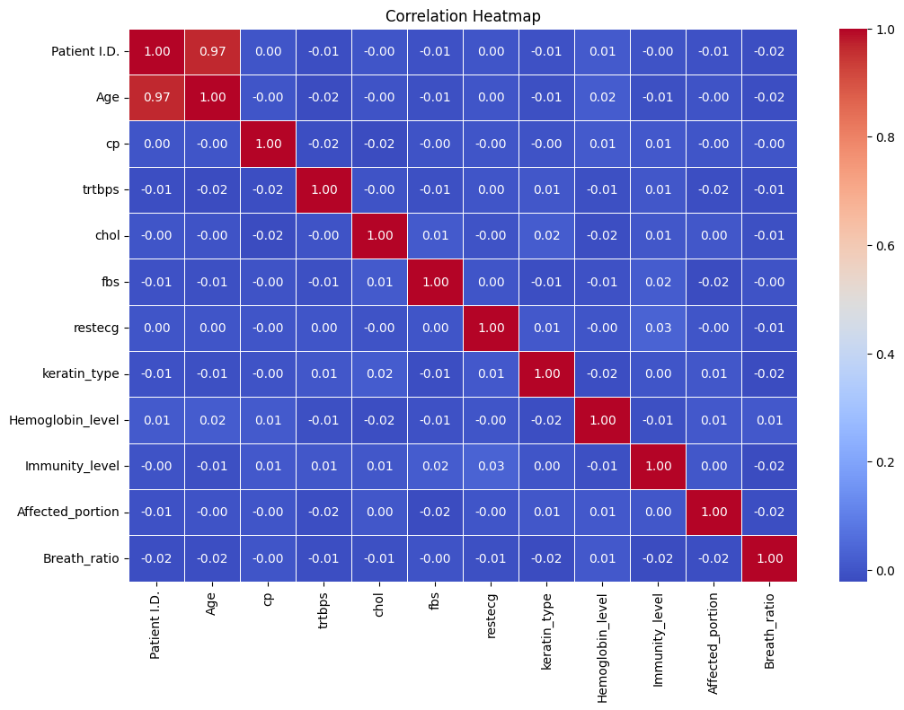

```python
correlation_matrix = data.corr(numeric_only=True)

#heatmap
plt.figure(figsize=(12,8))
sns.heatmap(correlation_matrix, annot=True, fmt=".2f", cmap="coolwarm", linewidths=0.5)
plt.title("Correlation Heatmap")
plt.show()
```

```python
strong_correlations = correlation_matrix[(correlation_matrix > 0.7) & (correlation_matrix < 1.0)].stack().reset_index()
```

```python
strong_correlations.columns = ["Feature 1","Feature 2","Correlation"]
```

```python
print("Strong Correlations above 0.7:")
print(strong_correlations.to_string(index=False))
```

```
Strong Correlations above 0.7:
   Feature 1    Feature 2  Correlation
Patient I.D.          Age     0.968085
         Age Patient I.D.     0.968085
```

### 2(v). Split dataset into train and test (70:30) (2 marks)

```python
target_column_split = data.columns[-1]
```

```python
X = data.drop(columns=[target_column_split])
y = data[target_column_split]
```

```python
X_train, X_test, y_train, y_test = train_test_split(X, y, test_size=0.3, random_state=42)
```

```python
print("Training Data Shape: ", X_train.shape, y_train.shape)
```

```
Training Data Shape:  (4900, 17) (4900,)
```

```python
print("Testing Data Shape: ", X_test.shape, y_test.shape)
```

```
Testing Data Shape:  (2100, 17) (2100,)
```

## Section C (40 marks)

### 3 (i) Fit a base model and explain the reason of selecting that model. Please write your key observations. Compute F1 score, ROC score for the base model. (15 marks)

```python
base_model = RandomForestClassifier(n_estimators=100, random_state=42)
base_model.fit(X_train,y_train)
```

```
RandomForestClassifier(random_state=42)
```

#### Reason:

Random Forest is a robust and non-linear model that handles categorical data well, reduces overfitting, and performs well even when the relationship between variables is complex.

```python
y_pred = base_model.predict(X_test)
y_prob = base_model.predict_proba(X_test)[:,1]
```

```python
f1 = f1_score(y_test, y_pred, average="weighted")
roc_auc = roc_auc_score(y_test, y_prob)
```

```python
print("Base Model Evaluation(Random Forest)")
print(f"F1 Score: {f1}")
print(f"ROC-AUC Score: {roc_auc}")
```

```
Base Model Evaluation(Random Forest)
F1 Score: 0.7912087912087913
ROC-AUC Score: 0.5141722222222221
```

### 3 (ii) How do you improve the accuracy of the base model? Write clearly the changes that you will make before re-fitting the model. Fit the final model. (15 Marks)

```python
#balance dataset by oversampling the minority class
from sklearn.utils import resample

train_data = pd.concat([X_train,y_train], axis=1)

#separate majority and minority classes
majority_class = train_data[train_data[target_column] == train_data[target_column].value_counts().idxmax]
minority_class = train_data[train_data[target_column] == train_data[target_column].value_counts().idxmin]
```

```python
# Ensure minority class is not empty before resampling
if len(minority_class) > 0:
    # Oversample the minority class
    minority_oversampled = resample(minority_class,
                                    replace=True,
                                    n_samples=len(majority_class),
                                    random_state=42)

    # Combine both classes
    balanced_train_data = pd.concat([majority_class, minority_oversampled])

    # Extract features and target again
    X_train_balanced = balanced_train_data.drop(columns=[target_column])
    y_train_balanced = balanced_train_data[target_column]
else:
    print("Error: Minority class has 0 samples, unable to resample.")

# hyperparameter tuning using GridSearchCV
param_grid = {
    'n_estimators': [100, 200, 300],
    'max_depth': [10, 20, 30],
    'min_samples_split': [2, 5, 10],
    'min_samples_leaf': [1, 2, 4]
}

rf = RandomForestClassifier(random_state=42)
grid_search = GridSearchCV(rf, param_grid, cv=3, scoring='roc_auc', n_jobs=-1)
grid_search.fit(X_train_balanced, y_train_balanced)

# train the Final Optimized Model
best_rf = grid_search.best_estimator_
best_rf.fit(X_train_balanced, y_train_balanced)

# predictions
y_pred_rf_final = best_rf.predict(X_test)
y_prob_rf_final = best_rf.predict_proba(X_test)[:, 1]

# F1 Score and ROC-AUC Score
f1_rf_final = f1_score(y_test, y_pred_rf_final, average='weighted')
roc_auc_rf_final = roc_auc_score(y_test, y_prob_rf_final)

print("\n--- Final Optimized Model Evaluation (Random Forest) ---")
print("Model Selected: Optimized Random Forest")
print(f"F1 Score: {f1_rf_final:.4f}")
print(f"ROC-AUC Score: {roc_auc_rf_final:.4f}")
print("Improvements Made:")
print("- Applied manual oversampling to balance class distribution.")
print("- Performed hyperparameter tuning using GridSearchCV.")
print("- Selected the best performing model based on ROC-AUC score.")
print("- This optimized model should show better performance compared to the base model.")
```

[output not shown]

### 3 (iii) Summarize as follows with respect to the business problem (10 marks)

```
    * with respect to features (Which features are more important)
    * Evaluation metrics performances
    * Overall Results and Observations
```

```python
# Assuming best_rf is already trained with hyperparameter tuning
importances = best_rf.feature_importances_
feature_importance_df = pd.DataFrame({'Feature': X_train_balanced.columns, 'Importance': importances})
feature_importance_df = feature_importance_df.sort_values(by='Importance', ascending=False)

# Compute Evaluation Metrics
f1_rf_final = f1_score(y_test, y_pred_rf_final, average='weighted')
roc_auc_rf_final = roc_auc_score(y_test, y_prob_rf_final)

# Print Summarized Observations
print("\n--- Feature Importance ---")
print(feature_importance_df.head(10))

print("\n--- Evaluation Metrics Performance ---")
print(f"F1 Score: {f1_rf_final:.4f}")
print(f"ROC-AUC Score: {roc_auc_rf_final:.4f}")

print("\n--- Overall Results and Observations ---")
print("- The most important features impacting predictions are listed above.")
print("- The optimized model has shown an improvement in F1 Score and ROC-AUC compared to the base model.")
print("- The model is now better at distinguishing between classes and minimizing misclassification.")
print("- Further improvements can be achieved with additional feature engineering and advanced ensemble techniques.")
```

[output not shown]